# Cover Letter for Submission to Statistical Analysis and Data Mining

Katherine

Katherine Goode, PhD Candidate  
Iowa State University  
Department of Statistics  
Ames, IA 50011  
kgoode@iastate.edu

Dr. Jia Li  
Editor-In-Chief  
Statistical Analysis and Data Mining

October 7, 2020

Dear Dr. Jia Li and other editors of Statistical Analysis and Data Mining,

We submit for review an article entitled “Visual Diagnostics of a Model Explainer – Tools for the Assessment of LIME Explanations” by Katherine Goode and Dr. Heike Hofmann. In this manuscript, we present visual diagnostic tools for the explainable machine learning method LIME (local interpretable model agnostic explanations) developed by Marco Tulio Ribeiro, Sameer Singh, and Carlos Guestrin (2016). We confirm that this work is original, has not been previously published, and is not under consideration for publication elsewhere.

We believe this manuscript is appropriate for publication by Statistical Analysis and Data Mining, because explainable machine learning is an important aspect for gaining trust in machine learning models, and our manuscript addresses the need to assess explanations from the popular method LIME. LIME is intended to gain insight into black-box models by using a linear model to approximate the complex model in a local region of interest. We argue that without an assessment of the approximation, LIME becomes a black-box method that requires blind trust from the user. The visual diagnostics we propose allow for the assessment of LIME explanations and highlight common issues with LIME. Our manuscript encourages users of LIME to be cautious of the explanations produced without diagnosing the fit of the LIME linear model.

We have no conflicts of interest to disclose.

Thank you for your consideration. We look forward to your response.

Sincerely,

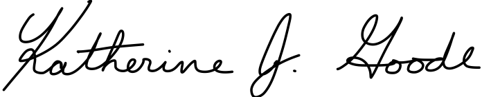

Katherine Goode, PhD Candidate  
Iowa State University  
Department of Statistics